# IODS course project

Wenzhong Zhang

# INTRODUCTION TO OPEN DATA SCIENCE

## HYMY005 (5 credits)

> **General info**
- Language: English, campus: City Centre.
- Period 2, starting 31 Oct 2017, ending 18 Dec 2017.
- Weekly class (optional): Tue 14-16, Unioninkatu 35, auditorium.
- Please bring a laptop computer (Mac/Windows/Linux) to the class.
- Prepare to work hard, several hours each week.

> **Link to Github repository**

https://github.com/timothyzwz/IODS-project

# Chapter 2: Regression and model validation

In this chapter, data regression and model validation is focused. A model dataset `learning2014` was given by the lecturer and originally consists of 60 variables and 183 responses from the survey “International Survey of Approaches to Learning”. The original data is available from [here](http://www.helsinki.fi/~kvehkala/JYTmooc/JYTOPKYS3-data.txt).

The analysis data is focused on certain variables: `gender`, `age`, `attitude`, `deep`, `stra`, `surf` and `Points` by combining questions in the `learning2014` data. The detailed definitions of the combination variables can be found [here](http://www.helsinki.fi/~kvehkala/JYTmooc/JYTOPKYS2-meta.txt) (at the bottom of the file).The analysis data is obtained from data wrangling exercise. All combination variables are scaled to the original scales (by taking the mean). Observations where the exam points `Points` variable is zero are excluded.

> **Step 1.** Reading and checking the data.

The analysis data is first read into the memmory and checked.

```r
learning2014_selected <- read.table("data/learning2014_selected.txt")
dim(learning2014_selected)
```

```
## [1] 166   7
```

```r
str(learning2014_selected)
```

```
## 'data.frame':    166 obs. of  7 variables:
##  $ gender  : Factor w/ 2 levels "F","M": 1 2 1 2 2 1 2 1 2 1 ...
##  $ Age     : int  53 55 49 53 49 38 50 37 37 42 ...
##  $ attitude: num  3.7 3.1 2.5 3.5 3.7 3.8 3.5 2.9 3.8 2.1 ...
##  $ deep    : num  3.58 2.92 3.5 3.5 3.67 ...
##  $ stra    : num  3.38 2.75 3.62 3.12 3.62 ...
##  $ surf    : num  2.58 3.17 2.25 2.25 2.83 ...
##  $ Points  : int  25 12 24 10 22 21 21 31 24 26 ...
```

The data consists of 166 observations and 7 variables. Of the 7 variables, gender is a two-level factor variable, age and Points are integer variables, and the rest is number variables.

> **Step 2.** Summary and graphical overview.

Here you can see an overview of the data and the summary of the variables in the data (**Figure 1**). Genders are marked with color (male = blue, female = red). As a first thought, there seems to be no correlation between `Age` and `attitude`, between `Age` and `deep`, between `Age` and `Points`, and between `deep` and `Points`. The highest correlation is found between the variables `Points` and `attitude`. If we split the `gender` variable, the correlation is high between `surf` and `deep` in male responses: while the same correlation simply does not apply to female responses.

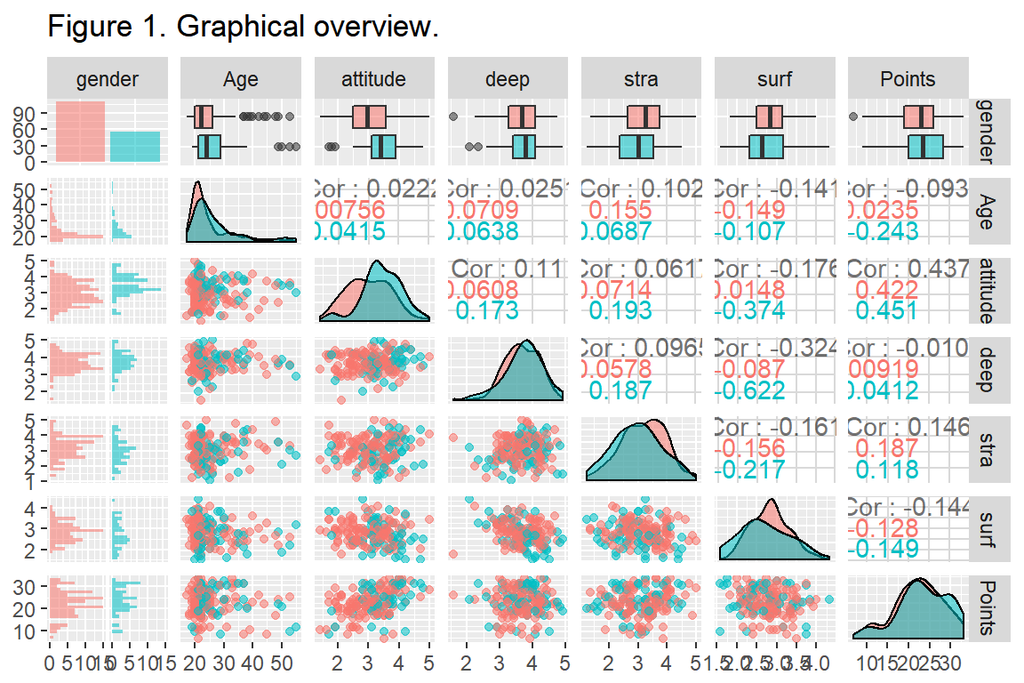

```r
library(GGally)
library(ggplot2)
p <- ggpairs(learning2014_selected, mapping = aes(col = gender, alpha = 0.7), lower = list(combo = wrap("facethist", bins = 20)), title = "Figure 1. Graphical overview.")
p
```

> **Step 3.** Regression fitting trial.

Three variables, namely `attitude`, `stra`, and `surf`, are chosen to fit a regression model where the exam points `Points` is the target variable. The summary of the fitted model is shown below. From the `t value` as well as the p-value `Pr`, it shows that the variable `surf` has no statistically significant relationship with the target `Points` variable.

```r
regression_trial1 <- lm(Points ~ attitude + stra + surf, data = learning2014_selected)
summary(regression_trial1)
```

```
##
## Call:
## lm(formula = Points ~ attitude + stra + surf, data = learning2014_selected)
##
## Residuals:
##      Min       1Q   Median       3Q      Max
## -17.1550  -3.4346   0.5156   3.6401  10.8952
##
## Coefficients:
##             Estimate Std. Error t value Pr(>|t|)
## (Intercept)  11.0171     3.6837   2.991  0.00322 **
## attitude      3.3952     0.5741   5.913 1.93e-08 ***
## stra          0.8531     0.5416   1.575  0.11716
## surf         -0.5861     0.8014  -0.731  0.46563
## ---
## Signif. codes:  0 '***' 0.001 '**' 0.01 '*' 0.05 '.' 0.1 ' ' 1
##
## Residual standard error: 5.296 on 162 degrees of freedom
## Multiple R-squared:  0.2074, Adjusted R-squared:  0.1927
## F-statistic: 14.13 on 3 and 162 DF,  p-value: 3.156e-08
```

> **Step 4.** Regression fitting.

The regression is conducted once again without the `surf` variable.

```r
regression_trial2 <- lm(Points ~ attitude + stra, data = learning2014_selected)
summary(regression_trial2)
```

```
##
## Call:
## lm(formula = Points ~ attitude + stra, data = learning2014_selected)
##
## Residuals:
##      Min       1Q   Median       3Q      Max
## -17.6436  -3.3113   0.5575   3.7928  10.9295
##
## Coefficients:
##             Estimate Std. Error t value Pr(>|t|)
## (Intercept)   8.9729     2.3959   3.745  0.00025 ***
## attitude      3.4658     0.5652   6.132 6.31e-09 ***
## stra          0.9137     0.5345   1.709  0.08927 .
## ---
## Signif. codes:  0 '***' 0.001 '**' 0.01 '*' 0.05 '.' 0.1 ' ' 1
##
## Residual standard error: 5.289 on 163 degrees of freedom
## Multiple R-squared:  0.2048, Adjusted R-squared:  0.1951
## F-statistic: 20.99 on 2 and 163 DF,  p-value: 7.734e-09
```

The summary report of the linear regression model gave a linear model with error information for the fitted data. The final regreesion model is $y=3.4658x_{1}+0.9137x_{2}+8.9729$, where $y=$`Points`, $x_{1}=$`attitude`, and $x_{2}=$`stra`. The Multiple R-squared (the coefficient of determination) is the proportion of the variance in the data that’s explained by the model. The more variables, the larger this will be. The Adjusted one reduces that to account for the number of variables in the model [[ref](https://stats.stackexchange.com/questions/59250/how-to-interpret-the-output-of-the-summary-method-for-an-lm-object-in-r)]. Here the multiple R-squred value is 0.2048, which is not an ideal fit for the data. However, R-squared cannot determine whether the coefficient estimates and predictions are biased, which is why later the residual plots are assessed. R-squared also does not indicate whether a regression model is adequate. A low R-squared value can be present for a good model, or a high R-squared value for a model that does not fit the data [[ref](http://blog.minitab.com/blog/adventures-in-statistics-2/regression-analysis-how-do-i-interpret-r-squared-and-assess-the-goodness-of-fit)].

> **Step 5.** Residual analysis.

In the linear regreesion model, the assumptions are:

1. Linearity: the target variable is modelled as a linear combination of the model parameters.
2. Normally distributed errors.
3. The errors are not correlated.
4. The errors have constant variance.
5. The size of a given error does not depend on the explanatory variables.

The residuals provide a method to explore the validity of the model assumptions. The following diagnostic plots are produced (**Figure 2**):

- Residuals vs Fitted values (*assumption 4*);
- Normal QQ-plot (*assumption 2*);
- Residuals vs Leverage (*single observation impact*).

**Figure 2**. Residual Plots (To see an interactive plot click [here](https://timothyzwz.shinyapps.io/IODS-project/), the file is hosted on shinnyapps server)

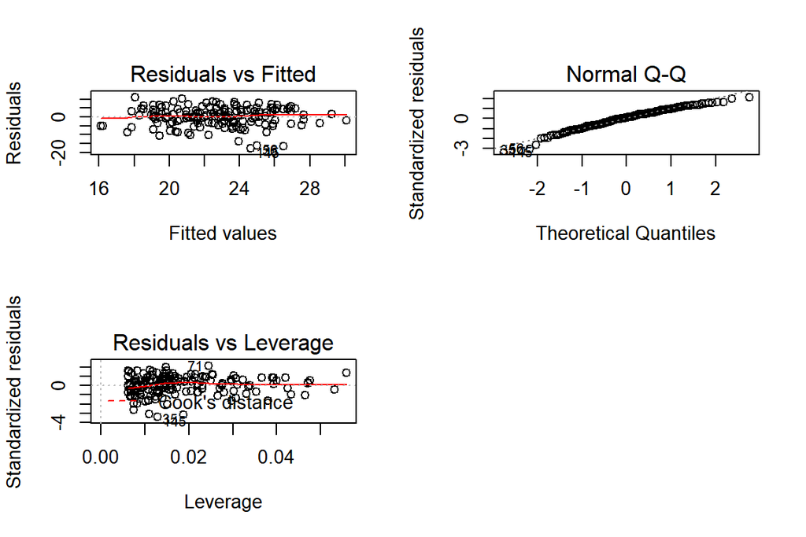

```r
par(mfrow = c(2,2))
plot(regression_trial2, which = c(1, 2, 5))
```

The following conclusions are drawn from the residual analysis:

- The Residuals vs Fitted values plot examines if the errors have constant variance. The graph shows a reasonable constant variance without any pattern.
- The Normal QQ-polt checks if the errors are normally distributed. We see from the graph a very good linear model fit, indicating a normally distributed error set.
- The Residuals vs Leverage confirms if there are any outliers with high leverage. From the graph, it shows that all the leverage are below 0.06, indicating good model fitting.

# Chapter 3: Logistic Regression

In this chapter, logitic regression is focused. Two model datasets were obtained from UCI Machine Learning Repository. This data approach student achievement in secondary education of two Portuguese schools. The data attributes include student grades, demographic, social and school related features) and it was collected by using school reports and questionnaires. Two datasets are provided regarding the performance in two distinct subjects: Mathematics (mat) and Portuguese language (por). The original data is available from [here](https://archive.ics.uci.edu/ml/datasets/Student+Performance).

> **Step 1.** Reading and checking the data.

The two datasets were joined by using the variables: `school`, `sex`, `age`, `address`, `famsize`, `Pstatus`, `Medu`, `Fedu`, `Mjob`, `Fjob`, `reason`, `nursery`, and `internet` as (student) identifier. The analysis data is obtained from data wrangling exercise. A new logical column `high_use` and it is TRUE if the average weekday and weekend alcohol consumption is greater than 2. In total, there are 35 variables and 382 observations.

```r
library(dplyr)
```

```r
library(tidyr)
library(ggplot2)
alc <- read.table("data/alc.txt", sep = " ", header = T)
dim(alc)
```

```
## [1] 382  35
```

```r
colnames(alc)
```

```
##  [1] "school"     "sex"        "age"        "address"    "famsize"
##  [6] "Pstatus"    "Medu"       "Fedu"       "Mjob"       "Fjob"
## [11] "reason"     "nursery"    "internet"   "guardian"   "traveltime"
## [16] "studytime"  "failures"   "schoolsup"  "famsup"     "paid"
## [21] "activities" "higher"     "romantic"   "famrel"     "freetime"
## [26] "goout"      "Dalc"       "Walc"       "health"     "absences"
## [31] "G1"         "G2"         "G3"         "alc_use"    "high_use"
```

> **Step 2.** Generating and Validating Hypothesis.

Hypotheses that I am interested in are:

1. High alcohol consumption (`alc_use`) is positively related with the amount of free time (`freetime`).
2. High alcohol consumption (`alc_use`) is positively related with failures (`failures`).
3. High alcohol consumption (`alc_use`) is negatively related with the average scores from final grade (`G3`).
4. High alcohol consumption (`alc_use`) is negatively related with health conditions (`health`).

#### Approach 1: Tabular Counting

Tabular counting of those variables vs. the average alcohol consumption in each category is produced. The positive correlation between `freetime` and `alc_use`, between `failures` and `alc_use` are very obviously. While the hypotheses 3 and 4 are not evident from the tables.

**Hypothesis 1:**

```r
alc %>% group_by(freetime) %>% summarise(count = n(), alcohol_consumption = mean(alc_use))
```

```
## # A tibble: 5 x 3
##   freetime count alcohol_consumption
##      <int> <int>               <dbl>
## 1        1    17            1.558824
## 2        2    65            1.738462
## 3        3   153            1.787582
## 4        4   111            2.040541
## 5        5    36            2.277778
```

**Hypothesis 2:**

```r
alc %>% group_by(failures) %>% summarise(count = n(), alcohol_consumption = mean(alc_use))
```

```
## # A tibble: 4 x 3
##   failures count alcohol_consumption
##      <int> <int>               <dbl>
## 1        0   334            1.818862
## 2        1    24            2.312500
## 3        2    19            2.368421
## 4        3     5            2.700000
```

**Hypothesis 3:**

```r
alc %>% group_by(G3) %>% summarise(count = n(), alcohol_consumption = mean(alc_use))
```

```
## # A tibble: 18 x 3
##       G3 count alcohol_consumption
##    <int> <int>               <dbl>
##  1     0     2            2.750000
##  2     2     1            3.500000
##  3     3     1            1.500000
##  4     4     7            2.000000
##  5     5     6            1.916667
##  6     6    22            1.931818
##  7     7     6            2.166667
##  8     8    27            1.777778
##  9     9     7            2.142857
## 10    10    64            2.093750
## 11    11    26            2.038462
## 12    12    81            2.018519
## 13    13    26            1.711538
## 14    14    38            1.789474
## 15    15    16            1.406250
## 16    16    38            1.671053
## 17    17     7            1.428571
## 18    18     7            1.142857
```

**Hypothesis 4:**

```r
alc %>% group_by(health) %>% summarise(count = n(), alcohol_consumption = mean(alc_use))
```

```
## # A tibble: 5 x 3
##   health count alcohol_consumption
##    <int> <int>               <dbl>
## 1      1    46            1.782609
## 2      2    44            1.943182
## 3      3    81            1.722222
## 4      4    67            1.865672
## 5      5   144            2.010417
```

#### Approach 2: Linear Regression

##### Regression

From linear regression modelling, hypotheses 1, 2 and 3 are all statistically significant (p<0.01), while it seems that hypothesis 4 is not valid.

**Hypothesis 1:**

```r
regression_hp1 <- lm(freetime ~ alc_use, data = alc)
summary(regression_hp1)
```

```
##
## Call:
## lm(formula = freetime ~ alc_use, data = alc)
##
## Residuals:
##      Min       1Q   Median       3Q      Max
## -2.59610 -0.41791 -0.06153  0.76028  1.93847
##
## Coefficients:
##             Estimate Std. Error t value Pr(>|t|)
## (Intercept)  2.88334    0.10749   26.82  < 2e-16 ***
## alc_use      0.17819    0.05048    3.53 0.000466 ***
## ---
## Signif. codes:  0 '***' 0.001 '**' 0.01 '*' 0.05 '.' 0.1 ' ' 1
##
## Residual standard error: 0.9703 on 380 degrees of freedom
## Multiple R-squared:  0.03175,    Adjusted R-squared:  0.0292
## F-statistic: 12.46 on 1 and 380 DF,  p-value: 0.0004665
```

**Hypothesis 2:**

```r
regression_hp2 <- lm(failures ~ alc_use, data = alc)
summary(regression_hp2)
```

```
##
## Call:
## lm(formula = failures ~ alc_use, data = alc)
##
## Residuals:
##     Min      1Q  Median      3Q     Max
## -0.5431 -0.2138 -0.1589 -0.1040  2.8960
##
## Coefficients:
##              Estimate Std. Error t value Pr(>|t|)
## (Intercept) -0.005779   0.063542  -0.091 0.927582
## alc_use      0.109782   0.029839   3.679 0.000268 ***
## ---
## Signif. codes:  0 '***' 0.001 '**' 0.01 '*' 0.05 '.' 0.1 ' ' 1
##
## Residual standard error: 0.5736 on 380 degrees of freedom
## Multiple R-squared:  0.0344, Adjusted R-squared:  0.03185
## F-statistic: 13.54 on 1 and 380 DF,  p-value: 0.0002678
```

**Hypothesis 3:**

```r
regression_hp3 <- lm(G3 ~ alc_use, data = alc)
summary(regression_hp3)
```

```
##
## Call:
## lm(formula = G3 ~ alc_use, data = alc)
##
## Residuals:
##      Min       1Q   Median       3Q      Max
## -11.3997  -1.9122   0.1254   2.1756   6.3378
##
## Coefficients:
##             Estimate Std. Error t value Pr(>|t|)
## (Intercept)  12.4499     0.3627  34.328   <2e-16 ***
## alc_use      -0.5251     0.1703  -3.083   0.0022 **
## ---
## Signif. codes:  0 '***' 0.001 '**' 0.01 '*' 0.05 '.' 0.1 ' ' 1
##
## Residual standard error: 3.274 on 380 degrees of freedom
## Multiple R-squared:  0.0244, Adjusted R-squared:  0.02184
## F-statistic: 9.505 on 1 and 380 DF,  p-value: 0.002198
```

**Hypothesis 4:**

```r
regression_hp4 <- lm(health ~ alc_use, data = alc)
summary(regression_hp4)
```

```
##
## Call:
## lm(formula = health ~ alc_use, data = alc)
##
## Residuals:
##     Min      1Q  Median      3Q     Max
## -2.9174 -0.7515  0.4144  1.3591  1.5250
##
## Coefficients:
##             Estimate Std. Error t value Pr(>|t|)
## (Intercept)  3.36442    0.15469  21.750   <2e-16 ***
## alc_use      0.11059    0.07264   1.522    0.129
## ---
## Signif. codes:  0 '***' 0.001 '**' 0.01 '*' 0.05 '.' 0.1 ' ' 1
##
## Residual standard error: 1.396 on 380 degrees of freedom
## Multiple R-squared:  0.006062,   Adjusted R-squared:  0.003447
## F-statistic: 2.318 on 1 and 380 DF,  p-value: 0.1287
```

##### Error Distribution

For hypotheses modeling, the error distributions were explored. From the picutres, only the Normal Q-Q plot for the 2nd hypothesis is questionable. This translate into that the error might not be normally distributed.

**Hypothesis 1:**

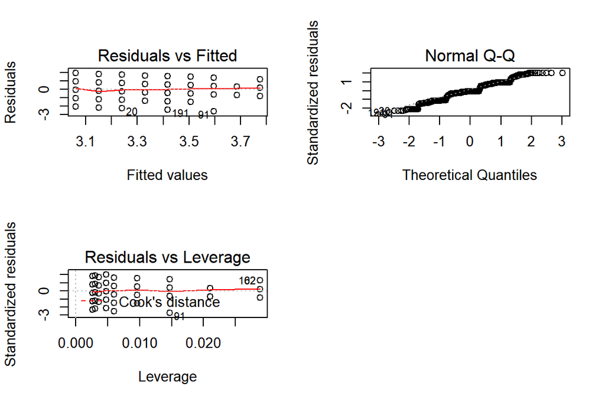

```r
par(mfrow = c(2,2))
plot(regression_hp1, which = c(1, 2, 5))
```

**Hypothesis 2:**

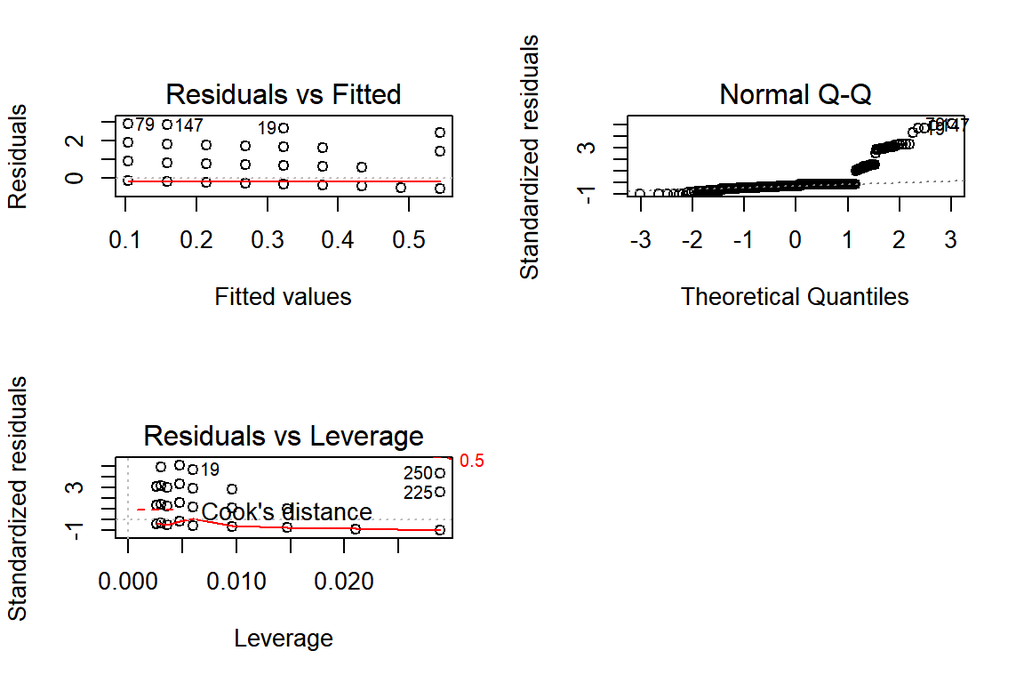

```r
par(mfrow = c(2,2))
plot(regression_hp2, which = c(1, 2, 5))
```

**Hypothesis 3:**

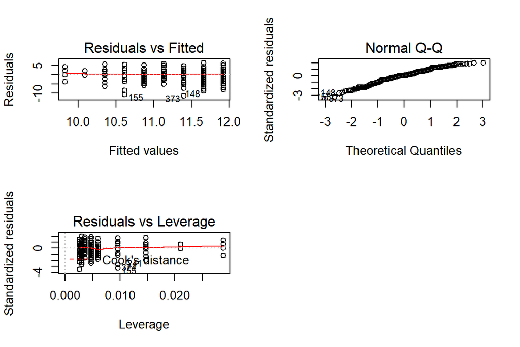

```r
par(mfrow = c(2,2))
plot(regression_hp3, which = c(1, 2, 5))
```

#### Approach 3: Logistic Regression

The aforementioned hypotheses are again studied by logistic regression using the variable `high_use`, which is `True` if the average weekday and weekend alcohol consumption is greater than 2.

**Hypothesis 1:**

```r
m1 <- glm(high_use ~ freetime, data = alc, family = "binomial")
summary(m1)
```

```
##
## Call:
## glm(formula = high_use ~ freetime, family = "binomial", data = alc)
##
## Deviance Residuals:
##     Min       1Q   Median       3Q      Max
## -1.0681  -0.8073  -0.8073   1.4442   1.9088
##
## Coefficients:
##             Estimate Std. Error z value Pr(>|z|)
## (Intercept)  -1.9909     0.4129  -4.821 1.43e-06 ***
## freetime      0.3457     0.1185   2.917  0.00353 **
## ---
## Signif. codes:  0 '***' 0.001 '**' 0.01 '*' 0.05 '.' 0.1 ' ' 1
##
## (Dispersion parameter for binomial family taken to be 1)
##
##     Null deviance: 465.68  on 381  degrees of freedom
## Residual deviance: 456.84  on 380  degrees of freedom
## AIC: 460.84
##
## Number of Fisher Scoring iterations: 4
```

```r
OR <- coef(m1) %>% exp
CI <- confint(m1) %>% exp
cbind(OR, CI)
```

```
##                   OR      2.5 %    97.5 %
## (Intercept) 0.136572 0.05940373 0.3008176
## freetime    1.412941 1.12365903 1.7897914
```

**Hypothesis 2:**

```r
m2 <- glm(high_use ~ failures, data = alc, family = "binomial")
summary(m2)
```

```
##
## Call:
## glm(formula = high_use ~ failures, family = "binomial", data = alc)
##
## Deviance Residuals:
##     Min       1Q   Median       3Q      Max
## -1.4506  -0.7998  -0.7998   1.3703   1.6097
##
## Coefficients:
##             Estimate Std. Error z value Pr(>|z|)
## (Intercept)  -0.9756     0.1212   -8.05 8.28e-16 ***
## failures      0.5327     0.1812    2.94  0.00328 **
## ---
## Signif. codes:  0 '***' 0.001 '**' 0.01 '*' 0.05 '.' 0.1 ' ' 1
##
## (Dispersion parameter for binomial family taken to be 1)
##
##     Null deviance: 465.68  on 381  degrees of freedom
## Residual deviance: 456.98  on 380  degrees of freedom
## AIC: 460.98
##
## Number of Fisher Scoring iterations: 4
```

```r
OR <- coef(m2) %>% exp
CI <- confint(m2) %>% exp
cbind(OR, CI)
```

```
##                    OR     2.5 %    97.5 %
## (Intercept) 0.3769473 0.2959175 0.4761582
## failures    1.7035936 1.1972813 2.4510832
```

**Hypothesis 3:**

```r
m3 <- glm(high_use ~ G3, data = alc, family = "binomial")
summary(m3)
```

```
##
## Call:
## glm(formula = high_use ~ G3, family = "binomial", data = alc)
##
## Deviance Residuals:
##     Min       1Q   Median       3Q      Max
## -1.2184  -0.8504  -0.7634   1.4307   1.7720
##
## Coefficients:
##             Estimate Std. Error z value Pr(>|z|)
## (Intercept)  0.09597    0.39319   0.244   0.8072
## G3          -0.08428    0.03389  -2.487   0.0129 *
## ---
## Signif. codes:  0 '***' 0.001 '**' 0.01 '*' 0.05 '.' 0.1 ' ' 1
##
## (Dispersion parameter for binomial family taken to be 1)
##
##     Null deviance: 465.68  on 381  degrees of freedom
## Residual deviance: 459.43  on 380  degrees of freedom
## AIC: 463.43
##
## Number of Fisher Scoring iterations: 4
```

```r
OR <- coef(m3) %>% exp
CI <- confint(m3) %>% exp
cbind(OR, CI)
```

```
##                    OR     2.5 %    97.5 %
## (Intercept) 1.1007277 0.5072618 2.3819208
## G3          0.9191715 0.8594673 0.9819718
```

**Hypothesis 4:**

```r
m4 <- glm(high_use ~ health, data = alc, family = "binomial")
summary(m4)
```

```
##
## Call:
## glm(formula = high_use ~ health, family = "binomial", data = alc)
##
## Deviance Residuals:
##     Min       1Q   Median       3Q      Max
## -0.8898  -0.8552  -0.8214   1.4954   1.6676
##
## Coefficients:
##             Estimate Std. Error z value Pr(>|z|)
## (Intercept) -1.19948    0.31804  -3.771 0.000162 ***
## health       0.09545    0.08156   1.170 0.241864
## ---
## Signif. codes:  0 '***' 0.001 '**' 0.01 '*' 0.05 '.' 0.1 ' ' 1
##
## (Dispersion parameter for binomial family taken to be 1)
##
##     Null deviance: 465.68  on 381  degrees of freedom
## Residual deviance: 464.29  on 380  degrees of freedom
## AIC: 468.29
##
## Number of Fisher Scoring iterations: 4
```

```r
OR <- coef(m4) %>% exp
CI <- confint(m4) %>% exp
cbind(OR, CI)
```

```
##                    OR     2.5 %   97.5 %
## (Intercept) 0.3013503 0.1586246 0.553819
## health      1.1001510 0.9392438 1.293985
```

##### **Summary of logistic regressions**

Odds ratios (OR) are used to compare the relative odds of the occurrence of the outcome of interest (`high_use`), given the change to the variable of interest (4 assumptions here).

**Table**. Comparison of ORs and their confidence intervals.

| Variable | OR | 2.5% | 97.5% |
| --- | --- | --- | --- |
| `freetime` | 1.41 | 1.12 | 1.79 |
| `failures` | 1.70 | 1.20 | 2.45 |
| `G3` | 0.92 | 0.86 | 0.98 |
| `health` | 1.10 | 0.94 | 1.29 |

From the results, we see that for `freetime` and `failures`, the ORs are all well above 1 and their confidence intervals does not include 1. For `G3`, the OR is below 1 and its confidence interval does not span till 1. For `health`, the OR is around 1 and the confidence interval spans 1. To sum it up, the first three hypotheses are statistially significant and correct, while the 4th hypothesis is not valid statistically.

> **Step 3.** Predictive Power of the Model.

Using the variables which, according to my logistic regression model, had a statistical relationship with high/low alcohol consumption (namely `freetime`, `failures` and `G3`), explore the predictive power of the model. The prediction is added as an additional column to the `alc` dataset. It is `TRUE` if the probability is greater than 0.5, otherwise it is `FALSE`.

```r
m <- glm(high_use ~ freetime + failures + G3, data = alc, family = "binomial")
probabilities <- predict(m, type = "response")
alc <- mutate(alc, probability = probabilities)
alc <- mutate(alc, prediction = probability > 0.5)
```

The tabulation of predictions vs. the actual values is listed here:

```r
table(high_use = alc$high_use, prediction = alc$prediction)
```

```
##         prediction
## high_use FALSE TRUE
##    FALSE   257   11
##    TRUE    105    9
```

The graphic visualization of both the actual values and the predictions is provided here:

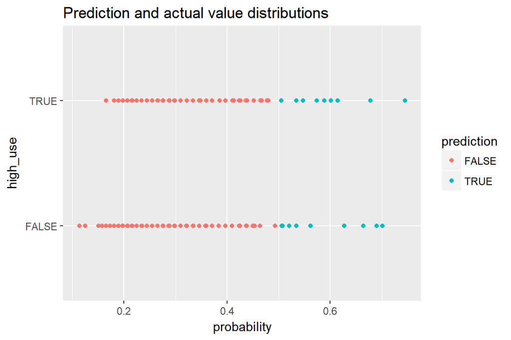

```r
g <- ggplot(alc, aes(x = probability, y = high_use, col = prediction))
g + geom_point() + ggtitle('Prediction and actual value distributions')
```

The total proportion of inaccurately classified individuals (= the training error) is computed here:

```r
table(high_use = alc$high_use, prediction = alc$prediction) %>% prop.table() %>% addmargins()
```

```
##         prediction
## high_use      FALSE       TRUE        Sum
##    FALSE 0.67277487 0.02879581 0.70157068
##    TRUE  0.27486911 0.02356021 0.29842932
##    Sum   0.94764398 0.05235602 1.00000000
```

```r
loss_func <- function(class, prob) {
  n_wrong <- abs(class - prob) > 0.5
  mean(n_wrong)
}
loss_func(class = alc$high_use, prob = alc$probability)
```

```
## [1] 0.3036649
```

The results showed that around 30% of the predictions are not correct, while on the other hand 70% of the predictions are correct. This is much better than simple guessing strategy, where the odds of guessing correctly would be approximately 50%.

> **Step 4.** Cross-validation.

10-fold cross-validation is performed subsequently. The prediction error is 0.31, which is larger than that of the model introduced in the Datacamp.

```r
library(boot)
cv <- cv.glm(data = alc, cost = loss_func, glmfit = m, K = 10)
cv$delta[1]
```

```
## [1] 0.3062827
```

Let’s try defining another model using many vairables, including `freetime`, `failures`, `studytime`, `absences`, `G1`, `G2`, `G3`, `romantic`, and `goout`. We use the exact same treatment to the model, and this time the prediction error from 10-fold cross-validation is around 0.25.

```r
m2 <- glm(high_use ~ freetime + failures + studytime + absences + G1 + G2 + G3 + romantic + goout, data = alc, family = "binomial")
probabilities2 <- predict(m2, type = "response")
alc <- mutate(alc, probability2 = probabilities2)
alc <- mutate(alc, prediction2 = probability > 0.5)
loss_func <- function(class, prob) {
  n_wrong <- abs(class - prob) > 0.5
  mean(n_wrong)
}
loss_func(class = alc$high_use, prob = alc$probability2)
```

```
## [1] 0.2303665
```

```r
cv2 <- cv.glm(data = alc, cost = loss_func, glmfit = m2, K = 10)
cv2$delta[1]
```

```
## [1] 0.2434555
```

> **Concluding remarks.**

Logistic regression modelling and prediction are explored in this chapter. The chosen assumptions are validated by means of linear regression modeling, logistic regression modelling and statistical check. Three our of the four assumptions (`freetime`, `failures` and `G3`) seemed to be statistically sound while the other one (`health`) did not seem to be relevant. The effect of alcohol consumption on the health conditions seem to have more long-term effect rather than short-term effect. The prediction of the `high_use` variable by the logistic regression model utilizing three assumptions generated a training error of approximately 30%. It is recommended that more vairables are taken into considerations to have a better-performing logistic regression model.

# Chapter 4: Clustering and classification

The topics of this chapter - clustering and classification - are handy and visual tools of exploring statistical data. Clustering means that some points (or observations) of the data are in some sense closer to each other than some other points. In other words, the data points do not comprise a homogeneous sample, but instead, it is somehow clustered.

> **Step 1.** Loading and checking the data.

The `boston` data summaries the housing values in suburbs of Boston back in 1970’s. It contains 506 observations of 14 different variables. Detailed explanation of the variables can be found [here](https://stat.ethz.ch/R-manual/R-devel/library/MASS/html/Boston.html). All the variables are either numeric or integerial.

```r
library(MASS)
data("Boston")
str(Boston)
```

```
## 'data.frame':    506 obs. of  14 variables:
##  $ crim   : num  0.00632 0.02731 0.02729 0.03237 0.06905 ...
##  $ zn     : num  18 0 0 0 0 0 12.5 12.5 12.5 12.5 ...
##  $ indus  : num  2.31 7.07 7.07 2.18 2.18 2.18 7.87 7.87 7.87 7.87 ...
##  $ chas   : int  0 0 0 0 0 0 0 0 0 0 ...
##  $ nox    : num  0.538 0.469 0.469 0.458 0.458 0.458 0.524 0.524 0.524 0.524 ...
##  $ rm     : num  6.58 6.42 7.18 7 7.15 ...
##  $ age    : num  65.2 78.9 61.1 45.8 54.2 58.7 66.6 96.1 100 85.9 ...
##  $ dis    : num  4.09 4.97 4.97 6.06 6.06 ...
##  $ rad    : int  1 2 2 3 3 3 5 5 5 5 ...
##  $ tax    : num  296 242 242 222 222 222 311 311 311 311 ...
##  $ ptratio: num  15.3 17.8 17.8 18.7 18.7 18.7 15.2 15.2 15.2 15.2 ...
##  $ black  : num  397 397 393 395 397 ...
##  $ lstat  : num  4.98 9.14 4.03 2.94 5.33 ...
##  $ medv   : num  24 21.6 34.7 33.4 36.2 28.7 22.9 27.1 16.5 18.9 ...
```

A graphical overview, a summary and a correlation matrix were plotted for `Boston` data and shown below. You can find the distribution of the data in the summary table with some statistical measures.

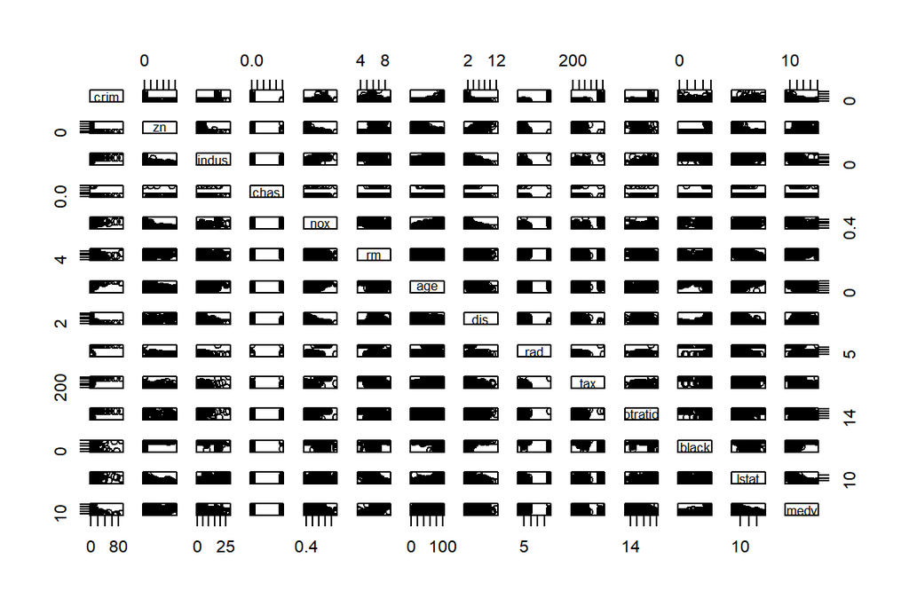

```r
library(corrplot)
library(tidyverse)
library(dplyr)
library(tidyr)
pairs(Boston)
```

```r
summary(Boston)
```

```
##       crim                zn             indus            chas
##  Min.   : 0.00632   Min.   :  0.00   Min.   : 0.46   Min.   :0.00000
##  1st Qu.: 0.08204   1st Qu.:  0.00   1st Qu.: 5.19   1st Qu.:0.00000
##  Median : 0.25651   Median :  0.00   Median : 9.69   Median :0.00000
##  Mean   : 3.61352   Mean   : 11.36   Mean   :11.14   Mean   :0.06917
##  3rd Qu.: 3.67708   3rd Qu.: 12.50   3rd Qu.:18.10   3rd Qu.:0.00000
##  Max.   :88.97620   Max.   :100.00   Max.   :27.74   Max.   :1.00000
##       nox               rm             age              dis
##  Min.   :0.3850   Min.   :3.561   Min.   :  2.90   Min.   : 1.130
##  1st Qu.:0.4490   1st Qu.:5.886   1st Qu.: 45.02   1st Qu.: 2.100
##  Median :0.5380   Median :6.208   Median : 77.50   Median : 3.207
##  Mean   :0.5547   Mean   :6.285   Mean   : 68.57   Mean   : 3.795
##  3rd Qu.:0.6240   3rd Qu.:6.623   3rd Qu.: 94.08   3rd Qu.: 5.188
##  Max.   :0.8710   Max.   :8.780   Max.   :100.00   Max.   :12.127
##       rad              tax           ptratio          black
##  Min.   : 1.000   Min.   :187.0   Min.   :12.60   Min.   :  0.32
##  1st Qu.: 4.000   1st Qu.:279.0   1st Qu.:17.40   1st Qu.:375.38
##  Median : 5.000   Median :330.0   Median :19.05   Median :391.44
##  Mean   : 9.549   Mean   :408.2   Mean   :18.46   Mean   :356.67
##  3rd Qu.:24.000   3rd Qu.:666.0   3rd Qu.:20.20   3rd Qu.:396.23
##  Max.   :24.000   Max.   :711.0   Max.   :22.00   Max.   :396.90
##      lstat            medv
##  Min.   : 1.73   Min.   : 5.00
##  1st Qu.: 6.95   1st Qu.:17.02
##  Median :11.36   Median :21.20
##  Mean   :12.65   Mean   :22.53
##  3rd Qu.:16.95   3rd Qu.:25.00
##  Max.   :37.97   Max.   :50.00
```

The correlation matrix shown here are in the form of a heat-map. Dark red color meaning negatively correlated, dark blue color meaning positively correlated, and white meaning no correlation. You can easily spot certain pairs that have stronger correlations from the graph.

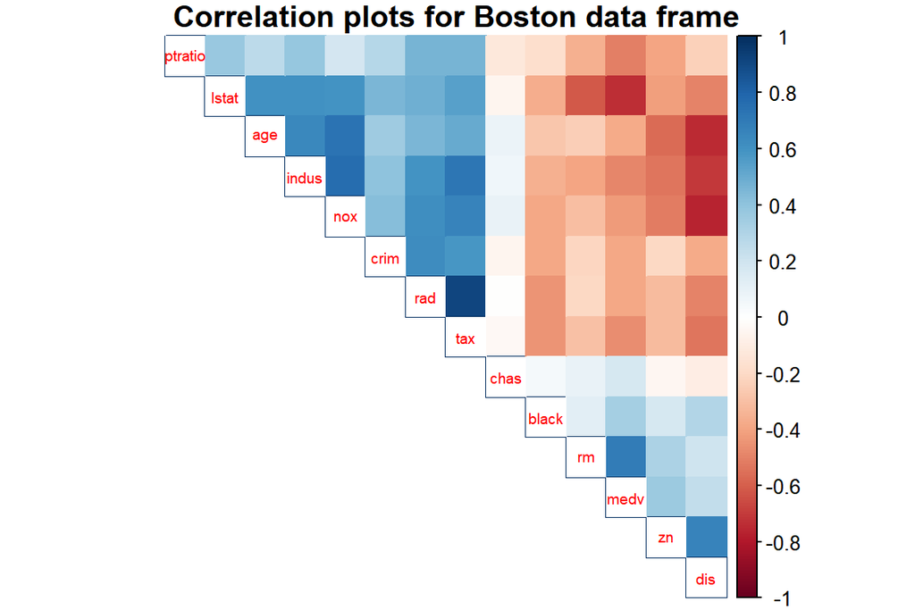

```r
cor_matrix <- cor(Boston)
corrplot(cor_matrix, method="color", order="hclust", type = "upper", cl.pos = "r", tl.pos = "d", tl.cex = 0.6, title = "Correlation plots for Boston data frame", mar=c(0,0,1,0))
```

> **Step 2.** Scaling and preparing the data for categorising.

The `Boston` data is standardised and its summary printed here. Scaling of data may be useful and/or necessary under certain circumstances (e.g. when variables span different ranges). Standardization is the scaling procedure which results in a zero mean and unit variance of any descriptor variable. For every data value the mean μ has to be subtracted, and the result has to be divided by the standard deviation σ (note that the order of these two operations must not be reversed):

```r
boston_scaled <- scale(Boston)
summary(boston_scaled)
```

```
##       crim                 zn               indus
##  Min.   :-0.419367   Min.   :-0.48724   Min.   :-1.5563
##  1st Qu.:-0.410563   1st Qu.:-0.48724   1st Qu.:-0.8668
##  Median :-0.390280   Median :-0.48724   Median :-0.2109
##  Mean   : 0.000000   Mean   : 0.00000   Mean   : 0.0000
##  3rd Qu.: 0.007389   3rd Qu.: 0.04872   3rd Qu.: 1.0150
##  Max.   : 9.924110   Max.   : 3.80047   Max.   : 2.4202
##       chas              nox                rm               age
##  Min.   :-0.2723   Min.   :-1.4644   Min.   :-3.8764   Min.   :-2.3331
##  1st Qu.:-0.2723   1st Qu.:-0.9121   1st Qu.:-0.5681   1st Qu.:-0.8366
##  Median :-0.2723   Median :-0.1441   Median :-0.1084   Median : 0.3171
##  Mean   : 0.0000   Mean   : 0.0000   Mean   : 0.0000   Mean   : 0.0000
##  3rd Qu.:-0.2723   3rd Qu.: 0.5981   3rd Qu.: 0.4823   3rd Qu.: 0.9059
##  Max.   : 3.6648   Max.   : 2.7296   Max.   : 3.5515   Max.   : 1.1164
##       dis               rad               tax             ptratio
##  Min.   :-1.2658   Min.   :-0.9819   Min.   :-1.3127   Min.   :-2.7047
##  1st Qu.:-0.8049   1st Qu.:-0.6373   1st Qu.:-0.7668   1st Qu.:-0.4876
##  Median :-0.2790   Median :-0.5225   Median :-0.4642   Median : 0.2746
##  Mean   : 0.0000   Mean   : 0.0000   Mean   : 0.0000   Mean   : 0.0000
##  3rd Qu.: 0.6617   3rd Qu.: 1.6596   3rd Qu.: 1.5294   3rd Qu.: 0.8058
##  Max.   : 3.9566   Max.   : 1.6596   Max.   : 1.7964   Max.   : 1.6372
##      black             lstat              medv
##  Min.   :-3.9033   Min.   :-1.5296   Min.   :-1.9063
##  1st Qu.: 0.2049   1st Qu.:-0.7986   1st Qu.:-0.5989
##  Median : 0.3808   Median :-0.1811   Median :-0.1449
##  Mean   : 0.0000   Mean   : 0.0000   Mean   : 0.0000
##  3rd Qu.: 0.4332   3rd Qu.: 0.6024   3rd Qu.: 0.2683
##  Max.   : 0.4406   Max.   : 3.5453   Max.   : 2.9865
```

```r
boston_scaled <- as.data.frame(boston_scaled)
```

A categorical variable of the crime rate is created in the Boston dataset (from the scaled crime rate). The quantiles are used as the break points in the categorical variable. The old crime rate variable from the dataset is deleted.

```r
bins <- quantile(boston_scaled$crim)
crime <- cut(boston_scaled$crim, breaks = bins, include.lowest = TRUE, labels = c("low", "med_low", "med_high", "high"))
boston_scaled <- dplyr::select(boston_scaled, -crim)
boston_scaled <- data.frame(boston_scaled, crime)
```

Divide the dataset to train and test sets, so that 80% of the data belongs to the train set.

```r
n <- nrow(boston_scaled)
ind <- sample(n,  size = n * 0.8)
train <- boston_scaled[ind,]
test <- boston_scaled[-ind,]
correct_classes <- test$crime
test <- dplyr::select(test, -crime)
```

> **Step 3.** Linear discriminant analysis (LDA).

Linear Discriminant analysis is a classification (and dimension reduction) method. It finds the (linear) combination of the variables that separate the target variable classes. Here we fit the `crime` variable by all other variables available in the dataset as predictors.

```r
lda.fit <- lda(crime ~ ., data = train)
lda.fit
```

```
## Call:
## lda(crime ~ ., data = train)
##
## Prior probabilities of groups:
##       low   med_low  med_high      high
## 0.2450495 0.2450495 0.2524752 0.2574257
##
## Group means:
##                   zn      indus        chas        nox         rm
## low       0.85429446 -0.9025526 -0.07348562 -0.8380582  0.4132054
## med_low  -0.07687567 -0.2889993 -0.03371693 -0.5918738 -0.1087105
## med_high -0.36869752  0.1119941  0.22945822  0.2980750  0.2137567
## high     -0.48724019  1.0170690 -0.12090214  1.0900681 -0.4894062
##                 age        dis        rad        tax     ptratio
## low      -0.8243386  0.8104561 -0.6779335 -0.7354120 -0.41337185
## med_low  -0.3475804  0.3968990 -0.5433656 -0.4542043 -0.03731554
## med_high  0.4221116 -0.3830665 -0.4042598 -0.3332710 -0.32815401
## high      0.8299319 -0.8595325  1.6386213  1.5144083  0.78135074
##               black       lstat         medv
## low       0.3797121 -0.73643419  0.502960442
## med_low   0.3130937 -0.12481983 -0.001260636
## med_high  0.1583684 -0.07494966  0.262394780
## high     -0.8006347  0.94498370 -0.791231351
##
## Coefficients of linear discriminants:
##                 LD1         LD2         LD3
## zn       0.11982767  0.71270862 -1.05897964
## indus    0.04514966 -0.27007475  0.39383615
## chas    -0.09514046 -0.06579345  0.02679539
## nox      0.45978764 -0.74552697 -1.20360501
## rm      -0.11401689 -0.08761176 -0.04143619
## age      0.32266854 -0.39187036 -0.14964930
## dis     -0.02270613 -0.29232761  0.46650673
## rad      3.22050801  0.86408406 -0.29403001
## tax     -0.05824320  0.00238599  0.76246944
## ptratio  0.07563313  0.12909435 -0.24731787
## black   -0.14037267  0.01809935  0.11404774
## lstat    0.19338714 -0.13191683  0.50879727
## medv     0.15303972 -0.34372347 -0.06714524
##
## Proportion of trace:
##    LD1    LD2    LD3
## 0.9549 0.0325 0.0126
```

The data is divided into four colours based on the `crime` category and the plot below shows the LDA results of them.

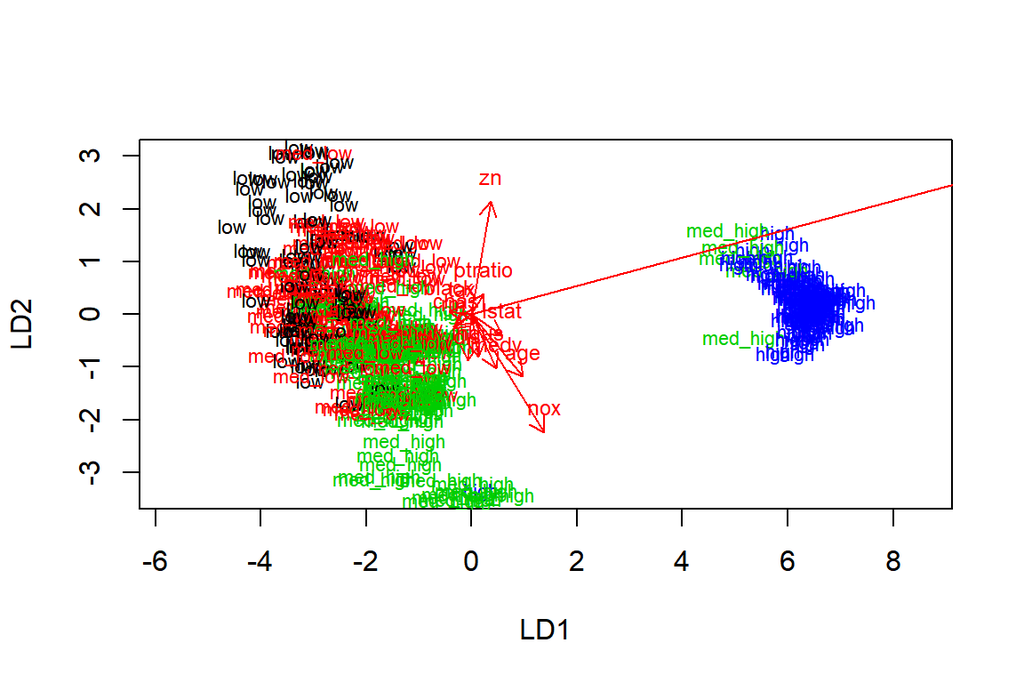

```r
lda.arrows <- function(x, myscale = 1, arrow_heads = 0.1, color = "red", tex = 0.75, choices = c(1,2)){
  heads <- coef(x)
  arrows(x0 = 0, y0 = 0,
         x1 = myscale * heads[,choices[1]],
         y1 = myscale * heads[,choices[2]], col=color, length = arrow_heads)
  text(myscale * heads[,choices], labels = row.names(heads),
       cex = tex, col=color, pos=3)
}
classes <- as.numeric(train$crime)
plot(lda.fit, dimen = 2, col = classes, pch = classes)
lda.arrows(lda.fit, myscale = 3)
```

> **Step 4.** Prediction by LDA.

The prediction of the classes with the LDA model on the test data was conducted.

```r
lda.pred <- predict(lda.fit, newdata = test)
```

Cross tabulate the results with the crime categories from the test set. It seems that most of the predictions are indeed correct.

```r
table(correct = correct_classes, predicted = lda.pred$class) %>% addmargins
```

```
##           predicted
## correct    low med_low med_high high Sum
##   low       19       8        1    0  28
##   med_low    4      19        4    0  27
##   med_high   0       8       15    1  24
##   high       0       0        0   23  23
##   Sum       23      35       20   24 102
```

The total proportion of inaccurately predicted individuals is computed here:

```r
table(correct = correct_classes, predicted = lda.pred$class) %>% prop.table() %>% addmargins()
```

```
##           predicted
## correct            low     med_low    med_high        high         Sum
##   low      0.186274510 0.078431373 0.009803922 0.000000000 0.274509804
##   med_low  0.039215686 0.186274510 0.039215686 0.000000000 0.264705882
##   med_high 0.000000000 0.078431373 0.147058824 0.009803922 0.235294118
##   high     0.000000000 0.000000000 0.000000000 0.225490196 0.225490196
##   Sum      0.225490196 0.343137255 0.196078431 0.235294118 1.000000000
```

```r
loss_func <- function(class, prob) {
  n_wrong <- class != prob
  mean(n_wrong)
}
loss_func(class = correct_classes, prob = lda.pred$class)
```

```
## [1] 0.254902
```

> **Step 5.** Distance measures.

Similarity or dissimilarity of objects can be measured with distance measures. There are many different measures for different types of data. The most common or “normal” distance measure is Euclidean distance.

Here, we reload and standardsize the `Boston` dataset.

```r
library(MASS)
data('Boston')
boston_scaled <- scale(Boston)
```

The distances between the observations are calculated:

1. Euclidean distance

```r
dist_eu <- dist(boston_scaled)
summary(dist_eu)
```

```
##    Min. 1st Qu.  Median    Mean 3rd Qu.    Max.
##  0.1343  3.4625  4.8241  4.9111  6.1863 14.3970
```

2. Manhattan distance

```r
dist_man <- dist(boston_scaled, method = "manhattan")
summary(dist_man)
```

```
##    Min. 1st Qu.  Median    Mean 3rd Qu.    Max.
##  0.2662  8.4832 12.6090 13.5488 17.7568 48.8618
```

To find the optimal K-means value, the total of within cluster sum of squares (WCSS) vs. the number of cluster changes is plotted.

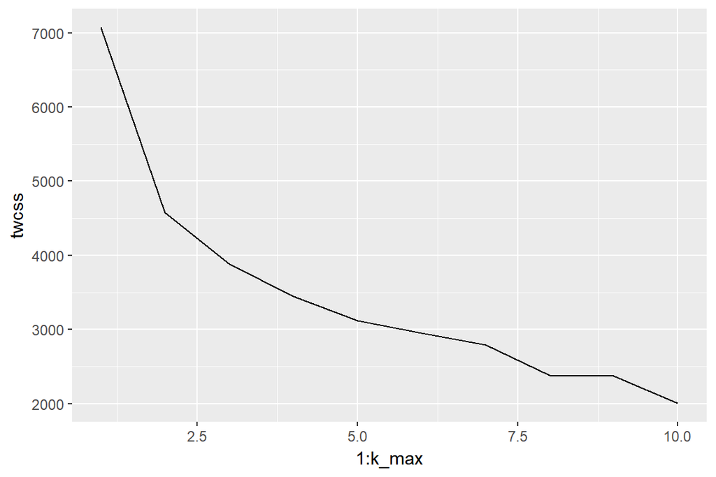

```r
library(ggplot2)
set.seed(123)
k_max <- 10
twcss <- sapply(1:k_max, function(k){kmeans(boston_scaled, k)$tot.withinss})
qplot(x = 1:k_max, y = twcss, geom = 'line')
```

The optimal number of clusters is when the total WCSS drops radically. In this case, the optimal K-means values is 2. The clusters are then visualised here:

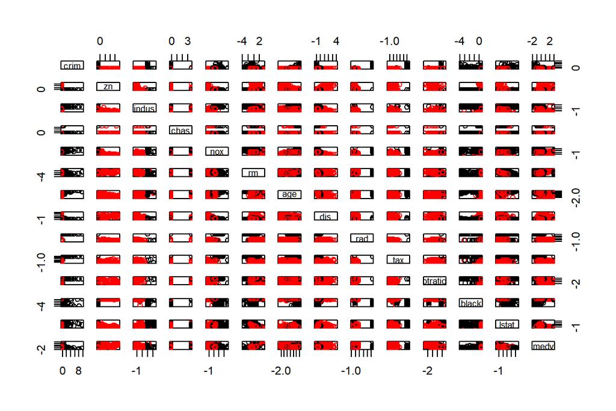

```r
km <-kmeans(boston_scaled, centers = 2)
pairs(boston_scaled, col = km$cluster)
```

The data in the standardised Boston dataset are classified into two clusters based on the K-means analysis. From the graph you can see that the data from the same cluster seem to be continurous and forms a lump in all distributions. However, we cannot simply say that the two clusters is the best fit for the current data. More realistic questions need to be taken into consideration when deciding the number of the clusters.

> **Concluding remarks.**

In the current chapter, we explored the clustering and classification of the data. LDA was used for fitting and predicting the variable based on the training data and gave a relatively good predicting power. The data are clustered by K-means analysis and the opitmal K-means values are explored.

# Chapter 5: Dimensionality reduction techniques

In this chapter, we learn the basics of two data science based ways of reducing the dimensions. The key method is principal component analysis (PCA), which reduces any number of measured (continuous) and correlated variables into a few uncorrelated components that collect together as much variance as possible from the original variables. The most important components can be then used for various purposes, e.g., drawing scatterplots and other fancy graphs that would be quite impossible to achieve with the original variables and too many dimensions.

> **Step 1.** Loading and checking the data.

The `human` data originates from the United Nations Development Programme.The Human Development Index (HDI) is a summary measure of average achievement in key dimensions of human development: a long and healthy life, being knowledgeable and have a decent standard of living. The HDI is the geometric mean of normalized indices for each of the three dimensions. The data contains 155 observations and 8 variables with the country as the `rolenames`. Detailed explanation of the variables can be found [here](http://hdr.undp.org/en/content/human-development-index-hdi). All the variables are either numeric or integerial (`dni` was changed from factor variable to numeric variable).

```r
human <- read.table("Data/human.txt")
human <- within(human, {
  gni <- as.character(gni)
})
human <- within(human, {
  gni <- as.numeric(sub(",", "", gni, fixed = TRUE))
})
str(human)
```

```
## 'data.frame':    155 obs. of  8 variables:
##  $ eduRatio  : num  1.007 0.997 0.983 0.989 0.969 ...
##  $ labRatio  : num  0.891 0.819 0.825 0.884 0.829 ...
##  $ lifebirth : num  81.6 82.4 83 80.2 81.6 80.9 80.9 79.1 82 81.8 ...
##  $ edutime   : num  17.5 20.2 15.8 18.7 17.9 16.5 18.6 16.5 15.9 19.2 ...
##  $ gni       : num  64992 42261 56431 44025 45435 ...
##  $ mortalityM: int  4 6 6 5 6 7 9 28 11 8 ...
##  $ teenbirth : num  7.8 12.1 1.9 5.1 6.2 3.8 8.2 31 14.5 25.3 ...
##  $ ParF      : num  39.6 30.5 28.5 38 36.9 36.9 19.9 19.4 28.2 31.4 ...
```

```r
dim(human)
```

```
## [1] 155   8
```

A graphical overview, a summary and a correlation matrix were plotted for `human` data and shown below. You can find the distribution of the data in the summary table with some statistical measures.

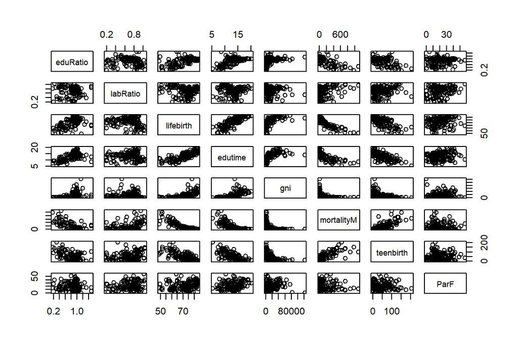

```r
library(corrplot)
library(tidyverse)
library(dplyr)
library(tidyr)
library(GGally)
library(ggplot2)
pairs(human)
```

```r
summary(human)
```

```
##     eduRatio         labRatio        lifebirth        edutime
##  Min.   :0.1717   Min.   :0.1857   Min.   :49.00   Min.   : 5.40
##  1st Qu.:0.7264   1st Qu.:0.5984   1st Qu.:66.30   1st Qu.:11.25
##  Median :0.9375   Median :0.7535   Median :74.20   Median :13.50
##  Mean   :0.8529   Mean   :0.7074   Mean   :71.65   Mean   :13.18
##  3rd Qu.:0.9968   3rd Qu.:0.8535   3rd Qu.:77.25   3rd Qu.:15.20
##  Max.   :1.4967   Max.   :1.0380   Max.   :83.50   Max.   :20.20
##       gni           mortalityM       teenbirth           ParF
##  Min.   :   581   Min.   :   1.0   Min.   :  0.60   Min.   : 0.00
##  1st Qu.:  4198   1st Qu.:  11.5   1st Qu.: 12.65   1st Qu.:12.40
##  Median : 12040   Median :  49.0   Median : 33.60   Median :19.30
##  Mean   : 17628   Mean   : 149.1   Mean   : 47.16   Mean   :20.91
##  3rd Qu.: 24512   3rd Qu.: 190.0   3rd Qu.: 71.95   3rd Qu.:27.95
##  Max.   :123124   Max.   :1100.0   Max.   :204.80   Max.   :57.50
```

The correlation matrix shown here are in the form of a heat-map. Dark red color meaning negatively correlated, dark blue color meaning positively correlated, and white meaning no correlation. You can easily spot certain pairs that have stronger correlations from the graph.

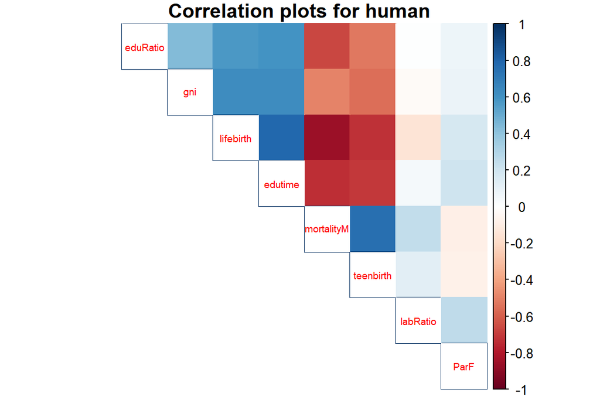

```r
cor(human) %>% corrplot(method="color", order="hclust", type = "upper", cl.pos = "r", tl.pos = "d", tl.cex = 0.6, title = "Correlation plots for human", mar=c(0,0,1,0))
```

> **Step 2.** Perform principal component analysis (PCA) on the not standardized human data.

The requested PCA was performed on the non-standardized human data.

```r
pca_human <- prcomp(human)
s <- summary(pca_human)
s
```

```
## Importance of components:
##                              PC1      PC2   PC3   PC4   PC5   PC6    PC7
## Standard deviation     1.854e+04 185.5219 25.19 11.45 3.766 1.566 0.1912
## Proportion of Variance 9.999e-01   0.0001  0.00  0.00 0.000 0.000 0.0000
## Cumulative Proportion  9.999e-01   1.0000  1.00  1.00 1.000 1.000 1.0000
##                           PC8
## Standard deviation     0.1591
## Proportion of Variance 0.0000
## Cumulative Proportion  1.0000
```

We can see from the summary of the PCA that the `gni` variable captured 100% of the variability. This is of course not correct. Why? Simply because the values are too huge compared to all other variables. Here the biplot is drawn and you can see that the arrow of `gni` is parallel to the PC1, meaning that they are basially the same determining factor during the analysis.

```r
pca_pr <- round(100*s$importance[2, ], digits = 1)
pca_pr
```

```
## PC1 PC2 PC3 PC4 PC5 PC6 PC7 PC8
## 100   0   0   0   0   0   0   0
```

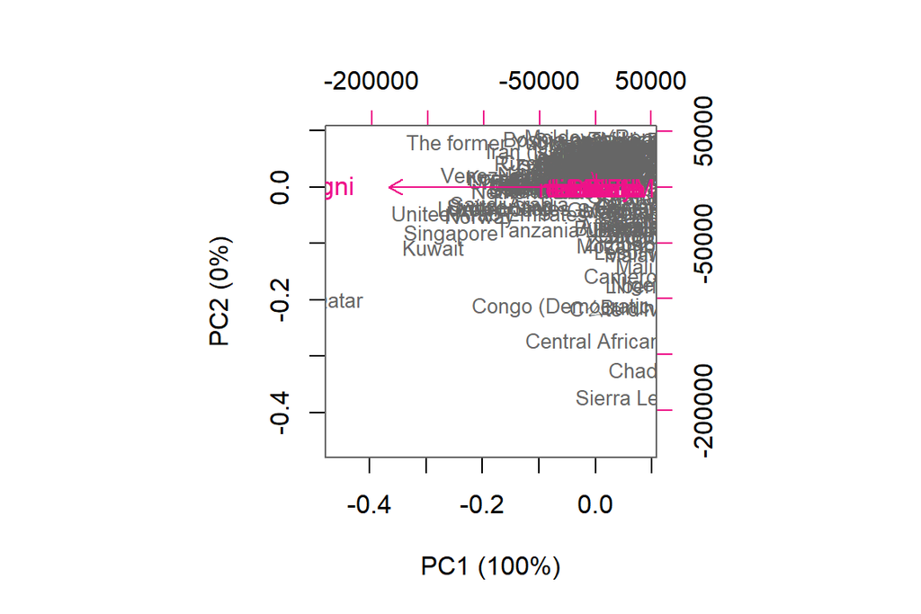

```r
pc_lab <- paste0(names(pca_pr), " (", pca_pr, "%)")
biplot(pca_human, cex = c(0.8, 1), col = c("grey40", "deeppink2"), xlab = pc_lab[1], ylab = pc_lab[2])
```

> **Step 3.** Perform principal component analysis (PCA) on the standardized human data.

To overcome the problem with regards to PCA analysis. The `human` data is first standardized.

```r
human_std <- scale(human)
summary(human_std)
```

```
##     eduRatio          labRatio         lifebirth          edutime
##  Min.   :-2.8189   Min.   :-2.6247   Min.   :-2.7188   Min.   :-2.7378
##  1st Qu.:-0.5233   1st Qu.:-0.5484   1st Qu.:-0.6425   1st Qu.:-0.6782
##  Median : 0.3503   Median : 0.2316   Median : 0.3056   Median : 0.1140
##  Mean   : 0.0000   Mean   : 0.0000   Mean   : 0.0000   Mean   : 0.0000
##  3rd Qu.: 0.5958   3rd Qu.: 0.7350   3rd Qu.: 0.6717   3rd Qu.: 0.7126
##  Max.   : 2.6646   Max.   : 1.6632   Max.   : 1.4218   Max.   : 2.4730
##       gni            mortalityM        teenbirth            ParF
##  Min.   :-0.9193   Min.   :-0.6992   Min.   :-1.1325   Min.   :-1.8203
##  1st Qu.:-0.7243   1st Qu.:-0.6496   1st Qu.:-0.8394   1st Qu.:-0.7409
##  Median :-0.3013   Median :-0.4726   Median :-0.3298   Median :-0.1403
##  Mean   : 0.0000   Mean   : 0.0000   Mean   : 0.0000   Mean   : 0.0000
##  3rd Qu.: 0.3712   3rd Qu.: 0.1932   3rd Qu.: 0.6030   3rd Qu.: 0.6127
##  Max.   : 5.6890   Max.   : 4.4899   Max.   : 3.8344   Max.   : 3.1850
```

The PCA is again run on the standardized data:

```r
pca_human_std <- prcomp(human_std)
s2 <- summary(pca_human_std)
s2
```

```
## Importance of components:
##                           PC1    PC2     PC3     PC4     PC5     PC6
## Standard deviation     2.0708 1.1397 0.87505 0.77886 0.66196 0.53631
## Proportion of Variance 0.5361 0.1624 0.09571 0.07583 0.05477 0.03595
## Cumulative Proportion  0.5361 0.6984 0.79413 0.86996 0.92473 0.96069
##                            PC7     PC8
## Standard deviation     0.45900 0.32224
## Proportion of Variance 0.02634 0.01298
## Cumulative Proportion  0.98702 1.00000
```

Now we can see that the PC 1 captured 53.6% of variance and PC 2 16.2%. The biplot is again drawn.

```r
pca_pr_std <- round(100*s2$importance[2, ], digits = 1)
pca_pr_std
```

```
##  PC1  PC2  PC3  PC4  PC5  PC6  PC7  PC8
## 53.6 16.2  9.6  7.6  5.5  3.6  2.6  1.3
```

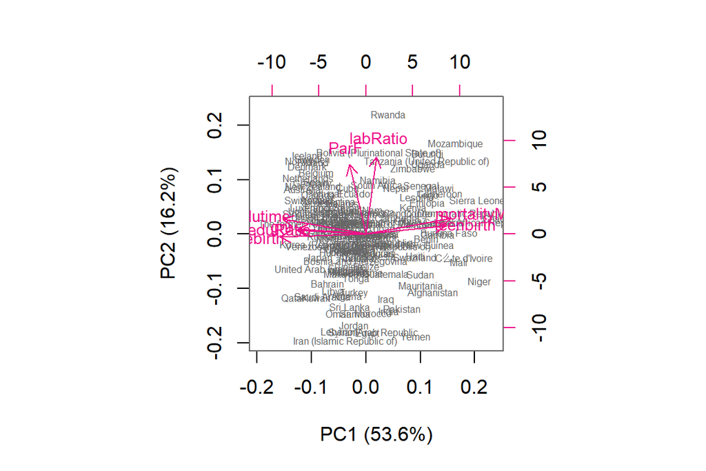

```r
pc_lab_std <- paste0(names(pca_pr), " (", pca_pr_std, "%)")
biplot(pca_human_std, cex = c(0.5, 0.8), col = c("grey40", "deeppink2"), xlab = pc_lab_std[1], ylab = pc_lab_std[2])
```

From the biplot, we can see that actually many variables are almost parallel to PC 1, including `edutime`, `eduRatio`, `teenbirth`, `dni`, `mortalityM` and `lifebirth`. The other two variables `ParF` and `labRatio` are almost paraelle to PC 2. We see that `dni` does not have determining power over all the data thanks to the standardization process.

> **Step 3.** Analysis of TEA data.

Loading the dataset from the package `FactoMineR` and explore the data briefly. The data has 300 observations and 36 variables. Most of the variables are factor variables with only the `age` variable as numeric.

```r
library(FactoMineR)
data(tea)
TEA_ <- tea
str(TEA_)
```

```
## 'data.frame':    300 obs. of  36 variables:
##  $ breakfast       : Factor w/ 2 levels "breakfast","Not.breakfast": 1 1 2 2 1 2 1 2 1 1 ...
##  $ tea.time        : Factor w/ 2 levels "Not.tea time",..: 1 1 2 1 1 1 2 2 2 1 ...
##  $ evening         : Factor w/ 2 levels "evening","Not.evening": 2 2 1 2 1 2 2 1 2 1 ...
##  $ lunch           : Factor w/ 2 levels "lunch","Not.lunch": 2 2 2 2 2 2 2 2 2 2 ...
##  $ dinner          : Factor w/ 2 levels "dinner","Not.dinner": 2 2 1 1 2 1 2 2 2 2 ...
##  $ always          : Factor w/ 2 levels "always","Not.always": 2 2 2 2 1 2 2 2 2 2 ...
##  $ home            : Factor w/ 2 levels "home","Not.home": 1 1 1 1 1 1 1 1 1 1 ...
##  $ work            : Factor w/ 2 levels "Not.work","work": 1 1 2 1 1 1 1 1 1 1 ...
##  $ tearoom         : Factor w/ 2 levels "Not.tearoom",..: 1 1 1 1 1 1 1 1 1 2 ...
##  $ friends         : Factor w/ 2 levels "friends","Not.friends": 2 2 1 2 2 2 1 2 2 2 ...
##  $ resto           : Factor w/ 2 levels "Not.resto","resto": 1 1 2 1 1 1 1 1 1 1 ...
##  $ pub             : Factor w/ 2 levels "Not.pub","pub": 1 1 1 1 1 1 1 1 1 1 ...
##  $ Tea             : Factor w/ 3 levels "black","Earl Grey",..: 1 1 2 2 2 2 2 1 2 1 ...
##  $ How             : Factor w/ 4 levels "alone","lemon",..: 1 3 1 1 1 1 1 3 3 1 ...
```

[output cut: 22 more lines]

```r
dim(TEA_)
```

```
## [1] 300  36
```

Here, we select a subset of the `tea` data set for analysis.

```r
kc <- c("Tea", "escape.exoticism", "spirituality", "healthy", "diuretic", "friendliness", "sophisticated", "slimming", "exciting", "relaxing", "effect.on.health")
tea_type_reason <- dplyr::select(TEA_, one_of(kc))
summary(tea_type_reason)
```

```
##         Tea                  escape.exoticism           spirituality
##  black    : 74   escape-exoticism    :142     Not.spirituality:206
##  Earl Grey:193   Not.escape-exoticism:158     spirituality    : 94
##  green    : 33
##         healthy            diuretic             friendliness
##  healthy    :210   diuretic    :174   friendliness    :242
##  Not.healthy: 90   Not.diuretic:126   Not.friendliness: 58
##
##            sophisticated        slimming          exciting
##  Not.sophisticated: 85   No.slimming:255   exciting   :116
##  sophisticated    :215   slimming   : 45   No.exciting:184
##
##         relaxing              effect.on.health
##  No.relaxing:113   effect on health   : 66
##  relaxing   :187   No.effect on health:234
##
```

```r
str(tea_type_reason)
```

```
## 'data.frame':    300 obs. of  11 variables:
##  $ Tea             : Factor w/ 3 levels "black","Earl Grey",..: 1 1 2 2 2 2 2 1 2 1 ...
##  $ escape.exoticism: Factor w/ 2 levels "escape-exoticism",..: 2 1 2 1 1 2 2 2 2 2 ...
##  $ spirituality    : Factor w/ 2 levels "Not.spirituality",..: 1 1 1 2 2 1 1 1 1 1 ...
##  $ healthy         : Factor w/ 2 levels "healthy","Not.healthy": 1 1 1 1 2 1 1 1 2 1 ...
##  $ diuretic        : Factor w/ 2 levels "diuretic","Not.diuretic": 2 1 1 2 1 2 2 2 2 1 ...
##  $ friendliness    : Factor w/ 2 levels "friendliness",..: 2 2 1 2 1 2 2 1 2 1 ...
##  $ sophisticated   : Factor w/ 2 levels "Not.sophisticated",..: 1 1 1 2 1 1 1 2 2 1 ...
##  $ slimming        : Factor w/ 2 levels "No.slimming",..: 1 1 1 1 1 1 1 1 1 1 ...
##  $ exciting        : Factor w/ 2 levels "exciting","No.exciting": 2 1 2 2 2 2 2 2 2 2 ...
##  $ relaxing        : Factor w/ 2 levels "No.relaxing",..: 1 1 2 2 2 2 2 2 2 2 ...
##  $ effect.on.health: Factor w/ 2 levels "effect on health",..: 2 2 2 2 2 2 2 2 2 2 ...
```

The selected data set is based on different tea types and different reasons for drinking tea. It is visualized here by bar plots.

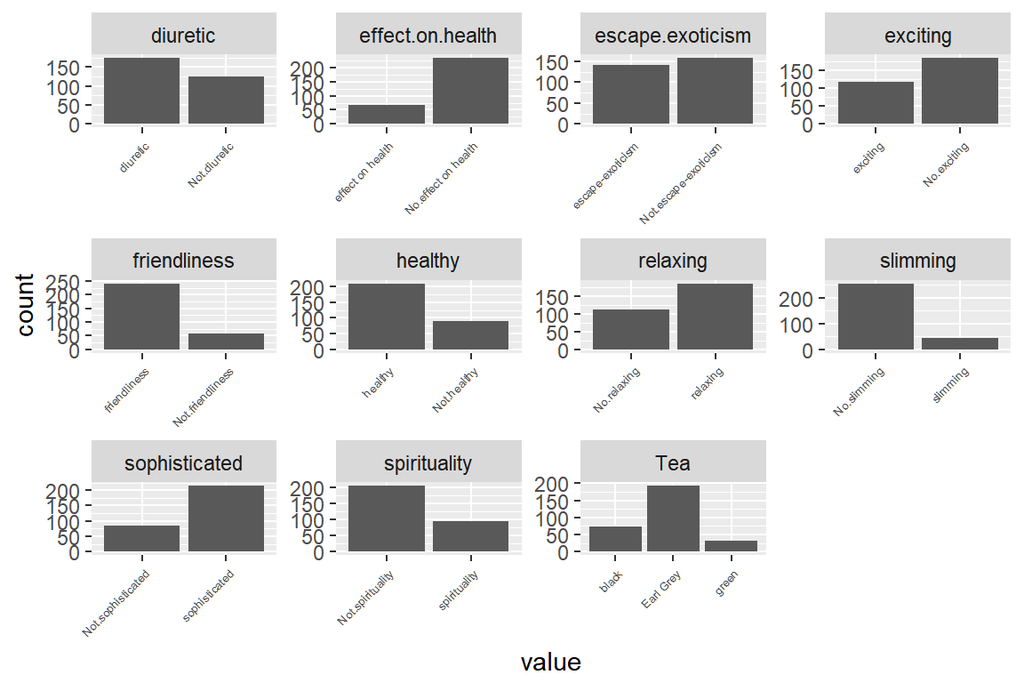

```r
gather(tea_type_reason) %>% ggplot(aes(value)) + facet_wrap("key", scales = "free") + geom_bar() + theme(axis.text.x = element_text(angle = 45, hjust = 1, size = 5))
```

The MCA of the selected data is conducted. The summary of the MCA is printed here:

```r
mca <- MCA(tea_type_reason, graph = FALSE)
summary(mca)
```

```
##
## Call:
## MCA(X = tea_type_reason, graph = FALSE)
##
##
## Eigenvalues
##                        Dim.1   Dim.2   Dim.3   Dim.4   Dim.5   Dim.6
## Variance               0.138   0.135   0.121   0.116   0.103   0.090
## % of var.             12.634  12.339  11.073  10.658   9.419   8.221
## Cumulative % of var.  12.634  24.973  36.045  46.703  56.122  64.342
##                        Dim.7   Dim.8   Dim.9  Dim.10  Dim.11  Dim.12
## Variance               0.080   0.077   0.066   0.062   0.055   0.049
## % of var.              7.325   7.017   6.066   5.687   5.057   4.506
## Cumulative % of var.  71.667  78.685  84.751  90.438  95.494 100.000
##
## Individuals (the 10 first)
##                         Dim.1    ctr   cos2    Dim.2    ctr   cos2
## 1                    |  0.637  0.982  0.285 | -0.550  0.750  0.213 |
## 2                    |  0.190  0.088  0.025 | -0.060  0.009  0.002 |
## 3                    |  0.055  0.007  0.004 | -0.482  0.575  0.339 |
## 4                    | -0.107  0.028  0.011 | -0.090  0.020  0.008 |
## 5                    |  0.007  0.000  0.000 |  0.153  0.058  0.023 |
## 6                    |  0.462  0.517  0.194 | -0.547  0.742  0.272 |
## 7                    |  0.462  0.517  0.194 | -0.547  0.742  0.272 |
## 8                    |  0.122  0.036  0.019 | -0.528  0.690  0.359 |
## 9                    |  0.528  0.674  0.258 | -0.129  0.041  0.015 |
## 10                   |  0.104  0.026  0.012 | -0.632  0.988  0.438 |
##                       Dim.3    ctr   cos2
## 1                     0.238  0.156  0.040 |
## 2                     0.586  0.948  0.234 |
## 3                    -0.066  0.012  0.006 |
## 4                    -0.495  0.675  0.226 |
## 5                    -0.388  0.416  0.146 |
## 6                    -0.189  0.098  0.032 |
## 7                    -0.189  0.098  0.032 |
## 8                    -0.306  0.259  0.121 |
## 9                    -0.323  0.287  0.096 |
## 10                   -0.027  0.002  0.001 |
##
## Categories (the 10 first)
```

[output cut: 20 more lines]

```
## Not.healthy           9.543 | -0.202  0.920  0.017 -2.285 |
## diuretic              0.568 |  0.354  5.470  0.173  7.193 |
##
## Categorical variables (eta2)
##                        Dim.1 Dim.2 Dim.3
## Tea                  | 0.009 0.159 0.244 |
## escape.exoticism     | 0.043 0.220 0.062 |
## spirituality         | 0.207 0.038 0.043 |
## healthy              | 0.303 0.305 0.017 |
## diuretic             | 0.246 0.001 0.173 |
## friendliness         | 0.068 0.006 0.022 |
## sophisticated        | 0.177 0.048 0.010 |
## slimming             | 0.279 0.041 0.006 |
## exciting             | 0.039 0.224 0.231 |
## relaxing             | 0.062 0.082 0.518 |
```

Next, the variable biplot of the MCA is drawn.

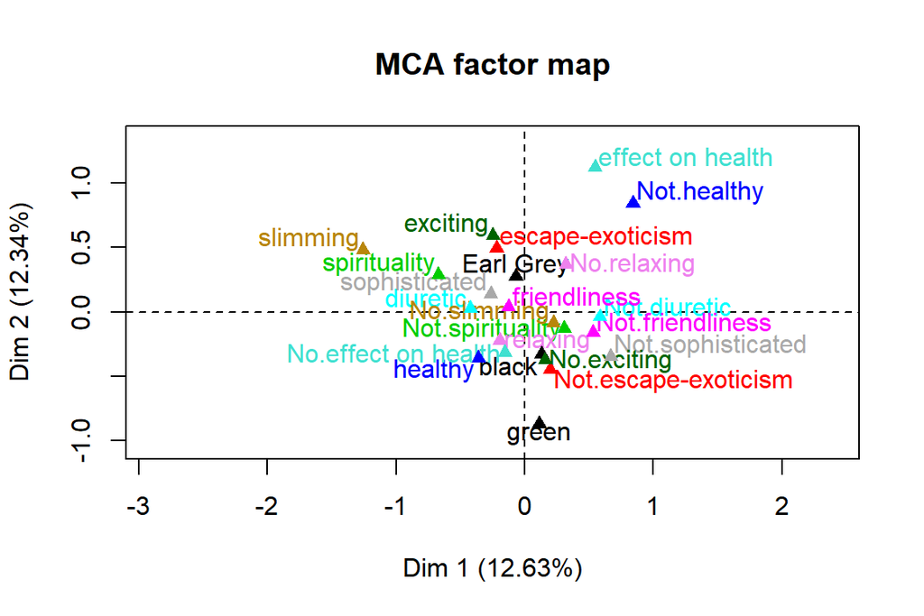

```r
plot(mca, invisible=c("ind"), habillage = "quali")
```

It seems that nothing really stand out in this MCA analysis. All dimensions captured similar amount of variablility and the most significant dimensions `Dim.1` and `Dim.2` is not strongly correlated with any of the variables.

> **Concluding remarks.**

In this chapter, PCA and MCA analysis were covered. For data including multiple variables, it is often useful to reduce the variable dimensions so that the data can be plot and visualized easilier. The most useful methods are PCA and MCA, both of which effectively reduce the dimension.